# Simple linear regression homework

```r
library(tidyverse)
library(janitor)
library(modelr)
library(ggfortify)
```

# 1 MVP

The file `project_management.csv` contains data sampled from the recent work schedule of a small construction company. Column `estimated_length` contains the estimated length of a building job in days, while column `actual_length` contains the actual recorded length of the job in days.

We are interested in determining the accuracy of the job estimations made by the company using simple linear regression, so we will eventually want to run a **simple linear regression** using `actual_length` as the dependent variable, and `estimated_length` as the independent variable.

- Load the data into a dataframe `project`

```r
project <- read_csv("data/project_management.csv")
```

```
## ──────────────────────────────────────────────────────── Delimiter: "," dbl
## (3): ...1, estimated_length, actual_length
```

- Plot the data, taking `estimated_length` as the independent variable and `actual_length` as the dependent variable.

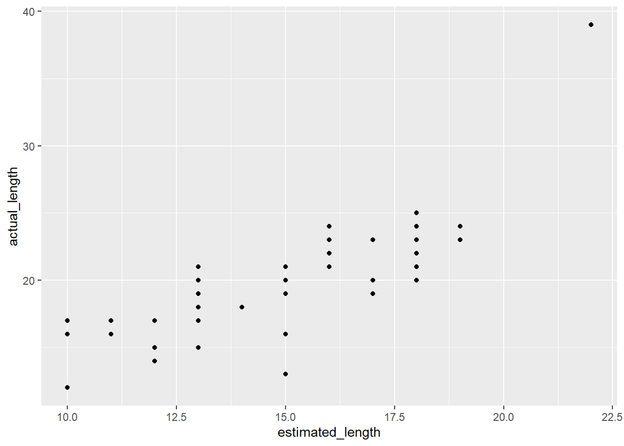

```r
(project_plot <- project %>%
  ggplot(aes(x = estimated_length,
             y = actual_length)) +
   geom_point())
```

- Calculate the correlation coefficient of `estimated_length` and `actual_length` and interpret the value you obtain.

```r
project %>%
  summarise(r = cor(estimated_length, actual_length))
```

| r |
| --- |
| 0.8046597 |

- Perform a simple linear regression using `actual_length` as the dependent variable, and `estimated_length` as the independent variable. Save the model object to a variable.

```r
(model <- lm(formula = actual_length ~ estimated_length, # line formula (outcome ~ predictor)
   data = project))
```

```
##
## Call:
## lm(formula = actual_length ~ estimated_length, data = project)
##
## Coefficients:
##      (Intercept)  estimated_length
##            1.416             1.223
```

- Interpret the regression coefficient of `estimated_length` (i.e. slope, gradient) you obtain from the model. How do you interpret the $r^2$ value reported by the model?

```r
summary(model)
```

```
##
## Call:
## lm(formula = actual_length ~ estimated_length, data = project)
##
## Residuals:
##     Min      1Q  Median      3Q     Max
## -6.7687 -1.6513  0.1195  1.1252 10.6669
##
## Coefficients:
##                  Estimate Std. Error t value Pr(>|t|)
## (Intercept)        1.4164     2.0069   0.706    0.484
## estimated_length   1.2235     0.1303   9.389 1.91e-12 ***
## ---
## Signif. codes:  0 '***' 0.001 '**' 0.01 '*' 0.05 '.' 0.1 ' ' 1
##
## Residual standard error: 2.606 on 48 degrees of freedom
## Multiple R-squared:  0.6475, Adjusted R-squared:  0.6401
## F-statistic: 88.16 on 1 and 48 DF,  p-value: 1.911e-12
```

- Is the relationship statistically significant? Remember, to assess this you need to check the $p$-value of the regression coefficient (or slope/gradient). But you should first check the regression diagnostic plots to see if the $p$-value will be reliable (don’t worry about any outlier points you see in the diagnostic plots, we’ll return to them in the extension).

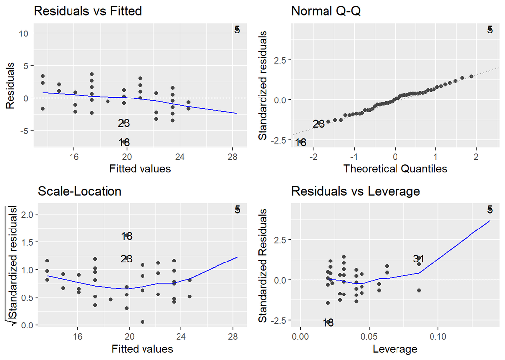

```r
autoplot(model)
```

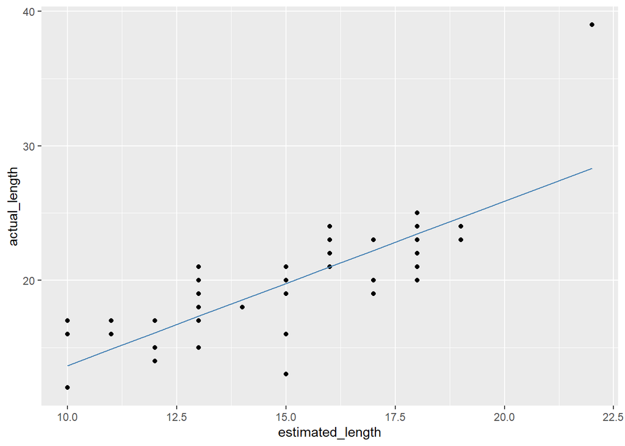

```r
project %>%
  add_predictions(model, var = "pred_length") %>% # var argument names column
  add_residuals(model, var = "resid_length") %>%
  ggplot(aes(x = estimated_length)) +
  geom_point(aes(y = actual_length)) +
  geom_line(aes(y = pred_length), colour = "steelblue")
```

p-value: 1.911e-12

The plot distributions look as we would hope and the line of best fit appears to fit our data points well. Our p-value is very small. All of these factors combined suggest that the relationship between the estimated_length and actual_length is statistically significant.

^^ should have mentioned outliers (point 5 and also point 18 to a lesser extent)